# Homosexualidad: ¿qué piensan los ecuatorianos?

2023-06-29

# Homofobia en el Ecuador

En Ecuador, las personas homosexuales han luchado incansablemente durante varios años por la garantía de sus derechos. Aunque la despenalización de la homosexualidad se logró en 1997 y la legalización del matrimonio igualitario en 2019, es importante destacar que tener igualdad de derechos no significa necesariamente que sean tratados de manera equitativa.

La homofobia se define como la “aversión hacia la homosexualidad o las personas homosexuales”<sup>[1]</sup>. Lamentablemente, la persistente homofobia en la sociedad ecuatoriana hace que los individuos homosexuales sigan enfrentando prejuicios y discriminación de forma constante. Estos prejuicios son capturados en la Encuesta Mundial de Valores, una encuesta realizada en diversos países del mundo, incluyendo Ecuador en 2013 y 2018. Con ilustra el gráfico 1, según la encuesta realizada en Ecuador en 2018, aproximadamente más del 30% de los ecuatorianos manifestó su rechazo hacia la idea de tener a un vecino homosexual.

Es importante destacar que la homofobia parece ser más prevalente entre los hombres que entre las mujeres. Según la misma encuesta de 2018, se observó que un 35% de los hombres encuestados manifestaron no querer tener un vecino homosexual, mientras que este porcentaje fue del 28% entre las mujeres. Una posible explicación es que los hombres homofóbicos consideran la homosexualidad como una perversión o enfermedad que amenaza su masculinidad. Un estudio de<sup>[2]</sup> indica que los hombres homofóbicos carecen de empatía hacia las personas homosexuales, ya que las perciben como diferentes a los rasgos tradicionalmente asociados con la masculinidad, como la rudeza y la agresividad. Sin embargo, aquellos hombres que se identifican con características típicamente masculinas pero socialmente deseables, como la tenacidad y la determinación, tienden a mostrar menor nivel de homofobia. Esto resalta la importancia de abordar y educar a la sociedad en su conjunto, y de manera especial a los hombres, sobre el respeto hacia la diversidad sexual, al mismo tiempo que se trabaja para eliminar los estereotipos machistas arraigados.

[figure not shown]

# El matrimonio igualitario

El contraer matrimonio entre dos personas de cualquier sexo es uno de los derechos más básicos para la adecuada integración de las personas homosexuales a la sociedad civil. Sin embargo, en Ecuador solamente desde junio de 2019 se permite el matrimonio de personas del mismo sexo, años después de que dos parejas LGBTQ+ intentaran, sin éxito, casarse en un Registro Civil<sup>[3]</sup>. La encuesta del Barómetro de las Américas (AB), ya utilizada en anteriores artículos de El Quantificador, nos permite evaluar la evolución de la opinión pública sobre el matrimonio igualitario en el Ecuador, como se ve a continuación.

[figure not shown]

Afortunadamente, en Ecuador se ha observado un creciente respaldo a los derechos de las personas LGBTQ+. Entre los años 2010 y 2019, el apoyo al matrimonio entre personas del mismo sexo se duplicó, con un incremento de 18.34 puntos porcentuales. Sin embargo, es importante destacar una caída en dicho apoyo entre los años 2012 y 2014. Aunque no se puede afirmar con certeza la razón exacta de esta reducción, es muy probable que el intento fallido de matrimonio entre las activistas Pamela Troya y Gabriela Correa en 2013 haya sido un factor influyente en este sentido. En ese momento, el entonces presidente del país, Rafael Correa, un conservador de izquierda, reiteró su desaprobación hacia el matrimonio igualitario, así como también expresó su oposición al cambio de sexo en la cédula de identidad y al derecho de adopción por parte de parejas del mismo sexo, en favor de lo que él llamó “la familia tradicional”<sup>[4]</sup>.

Después de una denuncia presentada por Troya y Correa, una jueza rechazó el recurso, basándose en que la Constitución del Ecuador de 2008 establece el matrimonio únicamente entre un hombre y una mujer. La jueza también mencionó la “invocación de Dios en la Constitución” y afirmó que “no hay constitución sin valores ni principios”, a pesar de que Ecuador es un estado laico<sup>[6]</sup>. Sin embargo, el matrimonio igualitario finalmente fue aprobado después de un largo proceso, luego de otra denuncia presentada por Efraín Soria y Javier Benalcázar, quienes también fueron inicialmente negados en su intento de casarse en 2018.

¿Que ha sucedido desde la legalización del matrimonio igualitario? Utilizamos datos del INEC/Registro Civil para calcular el número de matrimonios del mismo sexo desde su legalización. A continuación ilustramos los resultados desde julio 2019 hasta diciembre 2022.

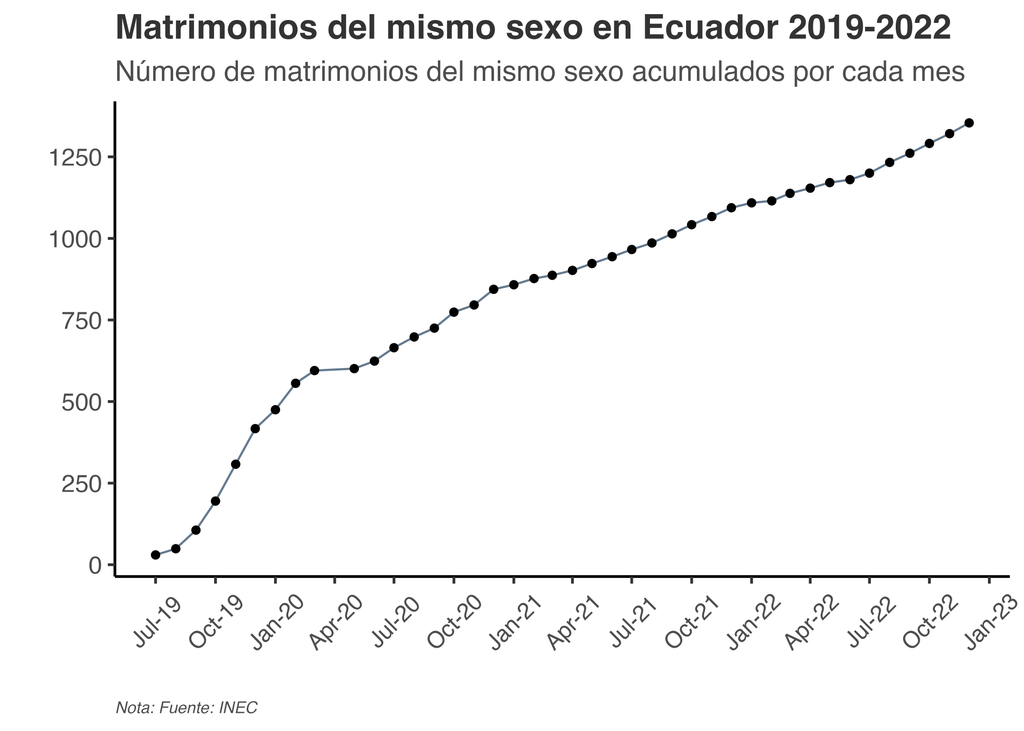

El gráfico muestra la distribución acumulada del número de matrimonios desde julio del 2019. El incremento más empinado ocurre en la segunda mitad del 2019, inmediatamente después de la legalización del matrimonio igualitario. Este fenómeno es entendible, considerando que muchas parejas esperaron por este momento para contraer matrimonio. Tras una parada en seco debido al confinamiento por el COVID-19 en abril 2020, se evidencia la normalización de los matrimonios del mismo sexo, quizás llegando a su tendencia normal. En cualquier caso, los matrimonios del mismo sexo siguen representando una proporción pequeña del total de matrimonios. El estudio de este fenómeno es complicado debido a la dificultad de obtener autoidentificación de orientación sexual en encuestas, sin embargo, algunos factores económico/laborales podrían disuadir a parejas homosexuales para casarse[^1].

# El derecho a la participación política

Más allá del matrimonio igualitario, la encuesta también consulta a los ciudadanos sobre su aprobación a los derechos políticos de las personas homosexuales. Específicamente, pregunta el grado de aprobación del derecho de las personas homosexuales de postularse a cargos políticos. A continuación mostramos los resultados.

[figure not shown]

Existe un constante aumento en la aprobación del derecho a postularse a cargos políticos de las personas homosexuales, superando el 40% de aprobación. Sin embargo, con más de un 50% de desaprobación, las posibilidades electorales de postulantes homosexuales están automáticamente en desventaja.

No es un secreto que la clase política ecuatoriana es conservadora, indiferente de su posición frente a la economía de mercado. El régimen que gobernó al país desde 2006 hasta 2017 tuvo muchos episodios donde sus rasgos conservadores se evidenciaron: además del rechazo al matrimonio igualitario, se rechazó la legalización del aborto, la “ideología de género” y se propuso un plan nacional que reemplace a los centros de salud por la familia en la educación sexual<sup>[8]</sup>. Por otro lado, los dos últimos gobiernos con tendencia a la derecha no motivaron las libertades sociales, vetando proyectos de ley que despenalizaban el aborto y abogando por menos inclusión en la educación[^2]<sup>[7,9,10]</sup>.

El electorado ecuatoriano es, en general, igualmente conservador. Los resultados de la encuesta presente determinaron que, si bien los valores progresistas han aumentado con el tiempo en el país, la intolerancia sigue muy arraigada, especialmente en torno al rechazo a las personas homosexuales y los servicios públicos para personas extranjeras. Las encuestas también revelan que no existe una relación clara entre la tendencia política y el conservadurismo, ya que el país, si bien se encuentra en el ala conservadora de la región, se sitúa en el centro de la dicotomía política izquierda y derecha<sup>[11]</sup>. De hecho, la autoidentificación política tampoco responde a los tradicionales valores e ideas económicas y sociales de estas tendencias políticas, por lo que se ha propuesto que la identificación política quizás responde más a personajes políticos<sup>[12]</sup>.

En conclusión, la verdad desnuda, pero sin desmanes ni burlas[^3], es que al Ecuador aun le queda mucho por recorrer en términos de la inclusión social, civil y política de las personas homosexuales. Aunque existen excepciones, como el caso del primer alcalde electo que es abiertamente gay<sup>[13]</sup>, la opinión pública así como las instituciones políticas y civiles aun son altamente heteronormativas. Sin embargo, juzgando por el constante crecimiento de la aprobación de los derechos de personas homosexuales, se puede tener una perspectiva optimista por lo que le espera al país en términos de inclusión, aun más considerando que son las personas más jóvenes las que comienzan a adoptar valores socialmente progresistas<sup>[11]</sup>.

# Notas Metodológicas

# Referencias

1. Española, R. A. (2001). Diccionario. *Madrid: Espasa*.

2. Verduzco, I. L., & Sánchez, T. E. R. (2011). La homofobia y su relación con la masculinidad hegemónica en méxico. *Revista Puertorriqueña de Psicologı́a*, *22*(1), 101–121.

3. Castro, Mayuri. (2019). *Una breve cronología del matrimonio igualitario en Ecuador.* GK. https://gk.city/2019/06/17/cronologia-matrimonio-igualitario-ecuador/

4. El Universo. (2013). Rafael Correa desaprueba Matrimonio Igualitario. In *Política | Noticias | El Universo*. El Universo. https://www.eluniverso.com/noticias/2013/05/25/nota/955451/rafael-desaprueba-matrimonio-igualitario/

5. Benalcázar Alarcón, Patricio Vicente. (2018). El derecho humano Al Matrimonio Igualitario en Ecuador: Caso Correa y Troya vs Registro Civil. un litigio en Medio de una antinomia constitucional y el conservadurismo judicial. In *UASB*. Universidad Andina Simón Bolívar, Sede Ecuador. {https://repositorio.uasb.edu.ec/handle/10644/6455}

6. Vaca, Fermín. (2016). *Las razones por las que Ecuador se rezaga en el matrimonio igualitario*. Plan V. https://www.planv.com.ec/historias/sociedad/razones-que-ecuador-se-rezaga-el-matrimonio-igualitario

7. Reuters. (2016). *Dos mujeres se casan en Ecuador tras seis años de lucha por el matrimonio igualitario Reuters*. https://www.reuters.com/article/ecuador-matrimonio-idESKCN1UW0FL

8. *Rafael Correa rechaza la "absurda" y "peligrosísima" ideología de género - Infobae* . (2014). https://www.infobae.com/2014/01/03/1534727-rafael-correa-rechaza-la-absurda-y-peligrosisima-ideologia-genero/

9. *Lenin Moreno vetó el proyecto de ley que despenalizaba el aborto de emergencia en Ecuador por “imprecisiones” - Infobae* . (2020).https://www.infobae.com/america/america-latina/2020/09/26/lenin-moreno-veto-el-proyecto-de-ley-que-despenalizaba-el-aborto-de-emergencia-en-ecuador-por-imprecisiones/?utm_medium=Echobox&utm_source=Twitter#Echobox=1601123650

10. *Ecuador: el presidente Lasso veta parcialmente el proyecto de ley de aborto en casos de violación*. (2022). https://www.france24.com/es/am\%C3\%A9rica-latina/20220316-ecuador-ley-aborto-lasso-femisnismo

11. Moncagatta, P., Moscoso, A., Pachano, S., Montalvo, J. D., & Zechmeister, E. J. (Eds.). (2020). *The Political Culture of Democracy in Ecuador and in the Americas, 2018/19: Taking the Pulse of Democracy*. Latin American Public Opinion Project. https://www.vanderbilt.edu/lapop/ecuador/AB2018-19-Ecuador-Country-Report-Eng-V2-W-200903.pdf

12. Sánchez Pazmiño, Daniel. (2023). Honesty by Convenience: Corruption Tolerance in Ecuador. *The Philosophy, Politics and Economics Review*. {https://pressbooks.lib.vt.edu/pper/chapter/article-5/}

13. Carreño, Diego Rivas y Victor. (2023).*Ecuador tendrá por primera vez un alcalde abiertamente gay - Washington Blade: LGBTQ News, Politics, LGBTQ Rights, Gay News* . https://www.washingtonblade.com/2023/02/17/ecuador-tendra-por-primera-vez-un-alcalde-abiertamente-gay/